# Examen práctico 2

Andrés Millán

02 de junio de 2022

# 1 Ejercicio 1

Para este ejercicio utilizaremos el dataset `airquality`, el cual recoge datos relacionados con la calidad del aire en Nueva York.

```r
summary(airquality)
```

```
##      Ozone           Solar.R           Wind             Temp           Month            Day
##  Min.   :  1.00   Min.   :  7.0   Min.   : 1.700   Min.   :56.00   Min.   :5.000   Min.   : 1.0
##  1st Qu.: 18.00   1st Qu.:115.8   1st Qu.: 7.400   1st Qu.:72.00   1st Qu.:6.000   1st Qu.: 8.0
##  Median : 31.50   Median :205.0   Median : 9.700   Median :79.00   Median :7.000   Median :16.0
##  Mean   : 42.13   Mean   :185.9   Mean   : 9.958   Mean   :77.88   Mean   :6.993   Mean   :15.8
##  3rd Qu.: 63.25   3rd Qu.:258.8   3rd Qu.:11.500   3rd Qu.:85.00   3rd Qu.:8.000   3rd Qu.:23.0
##  Max.   :168.00   Max.   :334.0   Max.   :20.700   Max.   :97.00   Max.   :9.000   Max.   :31.0
##  NA's   :37       NA's   :7
```

Construyamos un diagrama de cajas que nos permita comprobar la distribución de la radiación solar (variable `Solar.R`, medida en langleys) en los meses de mayo, junio, julio, agosto y septiembre.

Para conseguirlo, convirtamos primero la columna `airquality$Month` en un factor:

```r
aire <- airquality
aire$Month <- factor(aire$Month, labels = c("Mayo", "Junio", "Julio", "Agosto", "Septiembre"))
summary(aire$Month)
```

```
##       Mayo      Junio      Julio     Agosto Septiembre
##         31         30         31         31         30
```

La distribución de la variable `Solar.R` en conjunto es

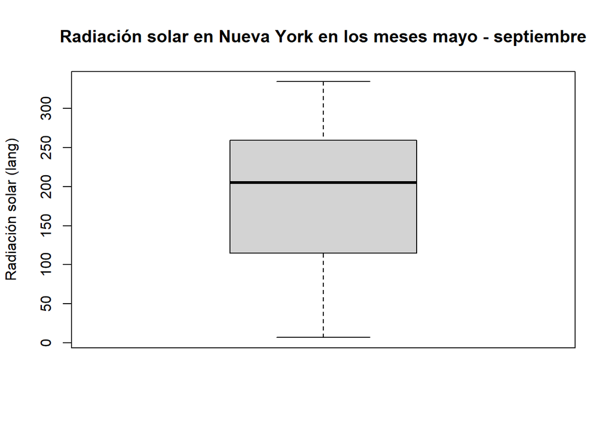

```r
boxplot(
  aire$Solar.R,
  main = "Radiación solar en Nueva York en los meses mayo - septiembre",
  ylab = "Radiación solar (lang)"
)
```

Y para cada mes, obtenemos

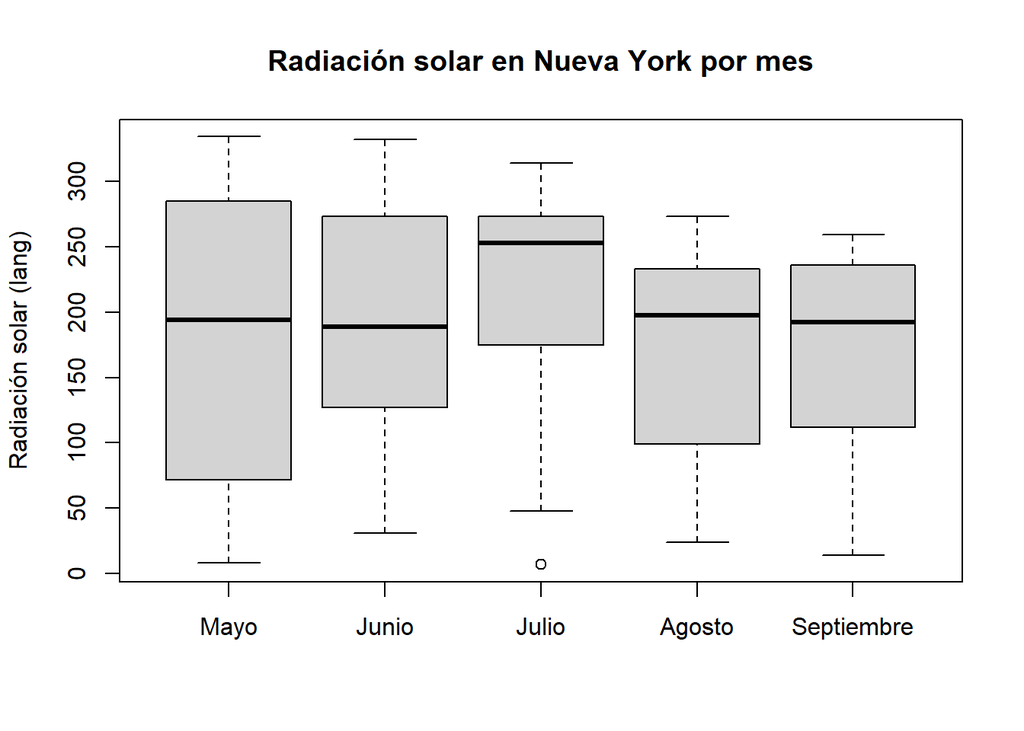

```r
boxplot(
  aire$Solar.R[aire$Month == "Mayo"],
  aire$Solar.R[aire$Month == "Junio"],
  aire$Solar.R[aire$Month == "Julio"],
  aire$Solar.R[aire$Month == "Agosto"],
  aire$Solar.R[aire$Month == "Septiembre"],
  main = "Radiación solar en Nueva York por mes",
  ylab = "Radiación solar (lang)",
  names = c("Mayo", "Junio", "Julio", "Agosto", "Septiembre")
)
```

¿Tendrán relación la radiación solar y la contaminación de Ozono?

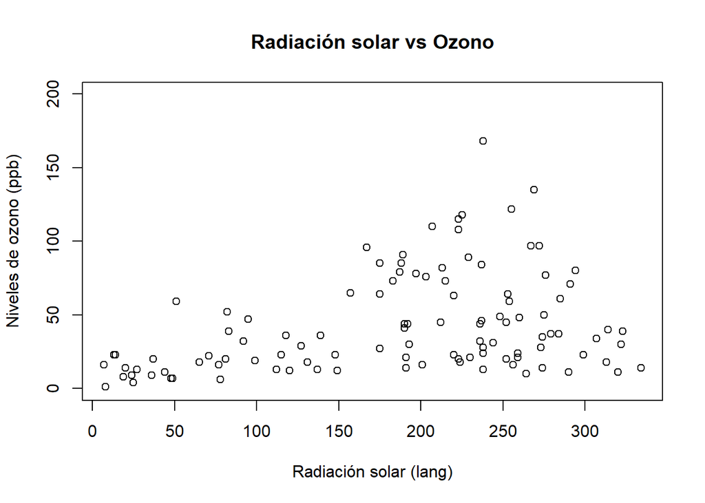

```r
plot(
  aire$Solar.R, aire$Ozone,
  main = "Radiación solar vs Ozono",
  xlab = "Radiación solar (lang)",
  ylab = "Niveles de ozono (ppb)",
  ylim = c(0, 200)
)
```

Es posible que exista una dependencia entre ambas variables. Ajustemos un modelo de regresión lineal para obtener una estimación. El modelo que vamos a ajustar es

$$\text{Ozono} = \beta_0 + \beta_1 \text{Solar.R}$$

Lo cual puede conseguirse con

```r
modelo <- lm(aire$Ozone ~ aire$Solar.R)
summary(modelo)
```

```
##
## Call:
## lm(formula = aire$Ozone ~ aire$Solar.R)
##
## Residuals:
##     Min      1Q  Median      3Q     Max
## -48.292 -21.361  -8.864  16.373 119.136
##
## Coefficients:
##              Estimate Std. Error t value Pr(>|t|)
## (Intercept)  18.59873    6.74790   2.756 0.006856 **
## aire$Solar.R  0.12717    0.03278   3.880 0.000179 ***
## ---
## Signif. codes:  0 '***' 0.001 '**' 0.01 '*' 0.05 '.' 0.1 ' ' 1
##
## Residual standard error: 31.33 on 109 degrees of freedom
##   (42 observations deleted due to missingness)
## Multiple R-squared:  0.1213, Adjusted R-squared:  0.1133
## F-statistic: 15.05 on 1 and 109 DF,  p-value: 0.0001793
```

Dicho p-valores nos indican una gran confianza en la correlación de ambas variables. El test de ANOVA muestra un resultado similar:

```r
anova(modelo)
```

```
## Analysis of Variance Table
##
## Response: aire$Ozone
##               Df Sum Sq Mean Sq F value    Pr(>F)
## aire$Solar.R   1  14780 14779.7  15.053 0.0001793 ***
## Residuals    109 107022   981.9
## ---
## Signif. codes:  0 '***' 0.001 '**' 0.01 '*' 0.05 '.' 0.1 ' ' 1
```

Superponiendo el modelo al gráfico anterior, obtenemos

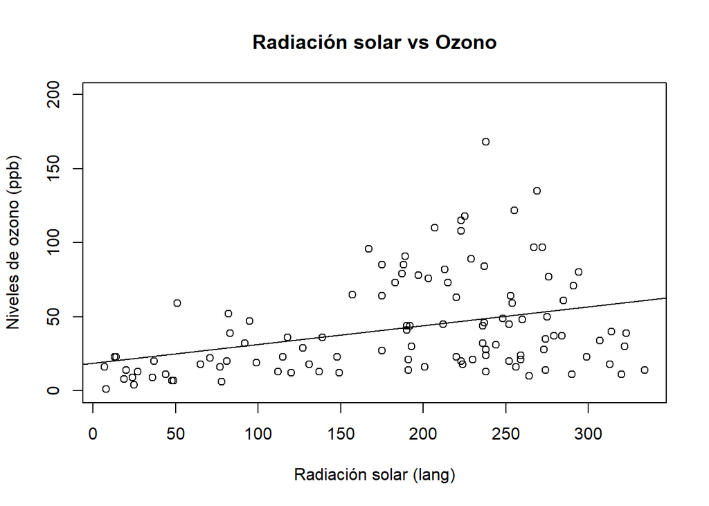

```r
plot(
  aire$Solar.R, aire$Ozone,
  main = "Radiación solar vs Ozono",
  xlab = "Radiación solar (lang)",
  ylab = "Niveles de ozono (ppb)",
  ylim = c(0, 200)
)
abline(modelo)
```

Lo cual nos confirma el efecto que esperábamos.

# 2 Ejercicio 2

La distribución de Pareto, de parámetros $a, b > 0$, viende dada por las funciones de densidad y distribución

$$\begin{aligned}
f(x) & = \frac{ab^a}{x^{a + 1}}, \quad & x \ge b \\
F(x) & = 1 - \left(\frac{b}{x}\right)^a, \quad & x \ge b
\end{aligned}$$

Con inversa

$$x = F^{-1}(\xi) = \frac{b}{\left( 1- \xi \right)^{1/a}}$$

```r
F_inversa <- function(xi, a, b) {
  b / (1 - xi)^(1 / a)
}
```

Podemos utilizar el método de la transformada inversa para generar $N = 1000$ valores aleatorios de la distribución de Pareto, con parámetros $a = 5$, $b = 4$:

```r
N <- 1000

xi <- runif(N)
a <- 5
b <- 4

x <- F_inversa(xi, a, b)
```

Los valores que hemos generado son:

```r
mean(x)
```

```
## [1] 5.071545
```

```r
sd(x)
```

```
## [1] 1.616764
```

Comprobemos gráficamente su distribución:

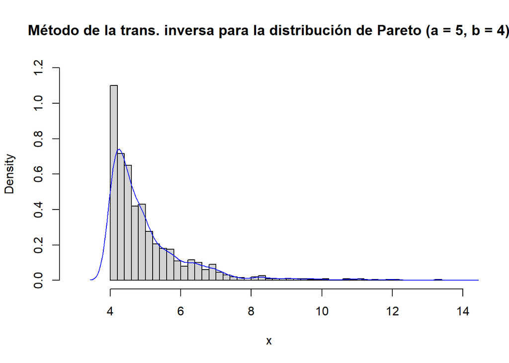

```r
hist(x,
  freq = FALSE,
  breaks = "FD",
  main = "Método de la trans. inversa para la distribución de Pareto (a = 5, b = 4)",
  xlim = c(3, 14), ylim = c(0, 1.2)
)
lines(density(x), col = "blue")
```

Podemos utilizar el test de Kolmogorov-Smirnov para comprobar que, en efecto, la distribución de los valores generados se asemeja a la de Pareto:

```r
distrib_pareto <- function(x, a, b) {
  ifelse(x >= b,
    1 - (b / x)^a,
    0
  )
}

ks.test(x, distrib_pareto, a = a, b = b)
```

```
##
##  One-sample Kolmogorov-Smirnov test
##
## data:  x
## D = 0.02537, p-value = 0.5405
## alternative hypothesis: two-sided
```